# 수리통계학 Ⅱ - chap 5 실습

## 2-(4). $\theta$의 사전 표본과 사후 표본을 생성하고 이를 이용하여 오즈비 $\eta = log(\theta/(1-\theta))$의 사전밀도함수, 사후밀도함수, 그리고 95% 최대사후구간을 구하고 그림 위에 표시

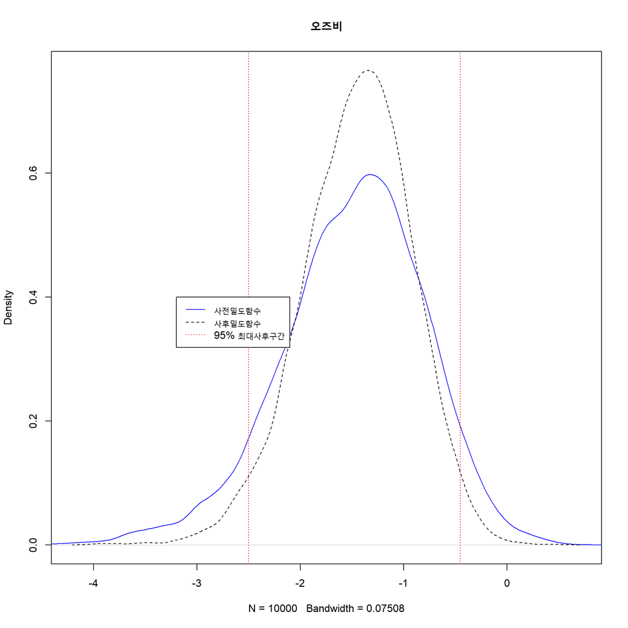

```r
HPDsample <- function(theta,level=0.95){
  N=length(theta)
  theta.sort=sort(theta)
  M=ceiling(N*level)
  nCI=N-M
  CI.width=rep(0,nCI)
  for(i in 1:nCI) CI.width[i]=theta.sort[i+M]-theta.sort[i]
  index=which.min(CI.width)
  HPD=c(theta.sort[index], theta.sort[index+M])
  return(HPD)
}
N=10000
theta1=rbeta(N,a,b)
theta2=rbeta(N,a2,b2)

eta1=log(theta1/(1-theta1))
eta2=log(theta2/(1-theta2))

HPD=HPDsample(eta2) #95% 최대사후구간

plot(density(eta2),type='n',main='오즈비')
lines(density(eta1), lty=1, col="blue")
lines(density(eta2), lty=2)
abline(v=HPD,lty=3, col = "red")
legend(-3.2,0.4, legend = c("사전밀도함수", "사후밀도함수", "95% 최대사후구간"),
       lty=c(1,2,3), col=c("blue","black","red"))
```

# 3. 불법 낙태에 대하여 찬성하는 사람들의 비율 $\theta$를 알고자 한다.

## 3-(1). 초기에 $\theta$의 분포는 $Beta(\alpha,\beta)$이고, 첫 번째 사람이 찬성한 다음에는 $Beta(\alpha+1,\beta)$

$$\mu_1 = \frac{\alpha}{\alpha+\beta} =
0.4 \\
\mu_2 = \frac{\alpha+1}{\alpha+1+\beta} = 0.45\\$$

```r
func <- function(x){
  alpha <- x[1]
  beta <- x[2]
  f1 <- alpha / (alpha + beta) - 0.4
  f2 <- (alpha + 1) / ((alpha + 1) + beta ) - 0.45
  return(c(f1, f2))
}

# multiroot 함수를 사용하여 해 찾기
library(rootSolve)
sol <- multiroot(func, start=c(1, 1))

a = sol$root[1]
b = sol$root[2]
a;b #[1] 4.399985 6.599955
```

```
## [1] 4.399985
```

```
## [1] 6.599955
```

$$\alpha=4.4, \beta=6.6$$

## 3-(2). 실제로 10명을 랜덤 추출한 결과 3명 찬성, 7명 반대 사전분포와 합성하여 사후분포 구하라.

```r
a=4.4
b=6.6
x=3
n=10

a2=a+x
b2=n-x+b
a2;b2 #[1] 7.4, [1] 13.6
```

```
## [1] 7.4
```

```
## [1] 13.6
```

$$사후분포\\
\pi(\theta|x_1,\cdots,x_n)\sim Beta(7.4,13.6)$$

## 3-(3). 새롭게 10명 추출 조사 예정. 새로운 표본에서 낙태에 찬성하는 사람들의 수에 대한 예측 분포

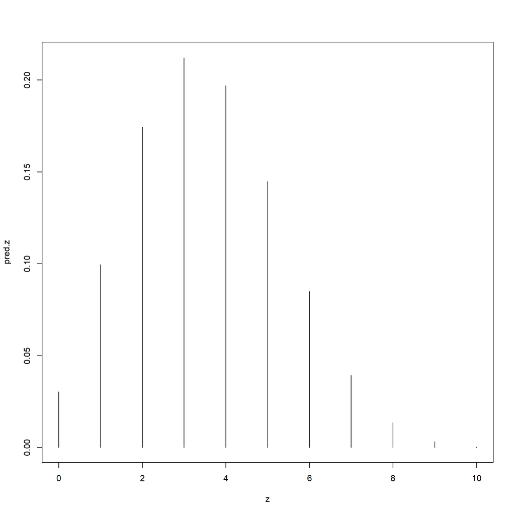

```r
m=10
z=c(0:10)
pred.z=gamma(m+1)/gamma(z+1)/gamma(m-z+1)*beta(a+z+x,b+n-x+m-z)/beta(a+x,b+n-x)
plot(z,pred.z,type = "h")
```

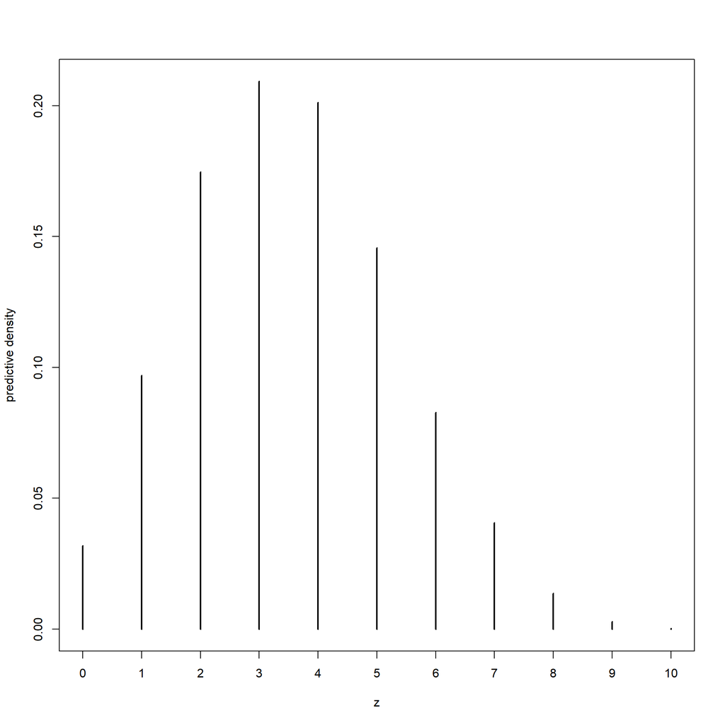

```r
#몬테칼로 기법
m=10
N=10000
theta=rbeta(N,a+x,b+n-x)
pred.z=c(1:(m+a))*0
for(z in c(0:m)) pred.z[z+1]=mean(dbinom(z,m,theta))
z=rbinom(N,m,theta)
plot(table(z)/N, type="h", xlab="z", ylab="predictive density", main="")
```

```r
mean(z) #예측 평균: [1] 3.5131
```

```
## [1] 3.5264
```

```r
var(z) #예측 분산: [1] 3.210549
```

```
## [1] 3.203223
```

# 4. 협심증 환자 12명을 대상으로 조사한 결과, 3명이 가슴통증 등 후유증을 보였다. 후유증 비율 $\theta$에 대한 사전 정보가 전혀 없다고 할 때, 13번째 환자가 후유증을 보일 예측 확률을 구하라.

$\alpha$와 $\beta$는 사전분포의 파라미터 (사전 정보가 없으므로 $\alpha=\beta=1$), s는 성공 횟수 (여기서는 후유증을 보인 환자 수 3명), n은 시도 횟수 (환자 수 12명)

$$사후분포\\
Beta(\alpha + s(successes), \beta + n - s) \\
Beta(1+3,1+12-3) = Beta(4,10)$$

$$E[\theta|data] = \alpha / (\alpha + \beta) = \\
4 / (4 + 10) = 0.2857$$

```r
# Prior parameters
alpha_prior <- 1
beta_prior <- 1

# Observed data
successes <- 3
trials <- 12

# Posterior parameters
alpha_posterior <- alpha_prior + successes
beta_posterior <- beta_prior + trials - successes

# Predicted probability for the next patient showing symptoms
predicted_probability <- alpha_posterior / (alpha_posterior + beta_posterior)
print(predicted_probability) #[1] 0.2857143
```

```
## [1] 0.2857143
```

# 5. 온라인 쇼핑몰 경품행사 실시, 사랑이는 열흘동안 매일 응모했지만 한 번도 당첨되지 못하였다. 쇼핑몰 관계자는 경품에 당첨될 확률이 1/10이라고 하였다.

## 5-(1). 경품의 당첨확률 $\theta$의 최우추정치는 얼마인가?

고전적 최우추정법에 의한 예측

사랑이가 10일 동안 매일 응모했지만 한 번도 당첨되지 않았다는 정보가 주어져 있습니다. 따라서 성공 횟수(successes)는 0회, 시도 횟수(trials)는 10회

이항 분포에서의 최우추정치 MLE는 다음과 같이 계산됩니다:

$$\hat{\theta} = \frac{성공 횟수}{시도 횟수} \\
\hat{\theta} = \frac{0}{10} = 0$$

즉, 사랑이의 경험을 바탕으로 할 때, 경품 당첨 확률의 최우추정치는 0입니다.

## 5-(2). (1)에서 구한 최우 추정치가 실제 $\theta$라고 가정할 때, 앞으로 사랑이가 20번 더 응모를 한다면 경품에 최소한 한번 이상 당첨될 확률은 얼마인가?

사랑이가 앞으로 20번 더 응모를 하면서 경품에 최소한 한 번 이상 당첨될 확률을 구하는 것은 “20번 중에 한 번도 당첨되지 않을 확률”을 구하고 그것을 1에서 빼주는 것

“20번 중에 한 번도 당첨되지 않을 확률”: $(1)^{20}$ (왜냐하면 각각의 응모가 독립적이며 각각의 실패 확률이 1 )

따라서 “경품에 최소한 한 번 이상 당첨될 확률”은
$$1 - (1)^{20} = 1 - 1 = 0$$

0%이다.

```r
1 - 1^20 #0
```

```
## [1] 0
```

## 5-(3). 쇼핑몰 관계자의 말을 사전정보로 간주하고 $\theta$에 대하여 $Beta(0.1,1)$ 사전분포를 가정하고 베이지안 추론을 수행. 사랑이가 20번 더 응모를 한다면 경품에 최소한 한 번 이상 당첨될 확률은 얼마인가? 사후분포로부터 $\theta$ 표본을 생성하고 이를 이용하여 확률을 추정하라.

$\alpha$와 $\beta$는 사전분포의 파라미터 ($\alpha=0.1, \beta=1$), s는 성공 횟수 (여기서는 당첨된 환자 수 0명), n은 시도 횟수 (응모한 일수 10일)

$$사후분포\\
Beta(\alpha + s(successes), \beta + n - s) \\
Beta(0.1+0,1+10-0) = Beta(0.1,11)$$

사전정보와 기존 경과로부터 업데이트된 $\theta$값인 $Beta(0.1,11)$의 기대값 $E[\theta|data] = \alpha / (\alpha + \beta)$를 사용하여 “20번 중에 한 번도 당첨되지 않을 확률”은 $(1-(\alpha / (\alpha+\beta)))^{20}$

따라서 “경품에 최소한 한 번 이상 당첨될 확률”은

$$1 - (1-(\frac{\alpha}{\alpha+\beta}))^{20} =\\
1 - (1-(\frac{0.1}{0.1+11}))^{20} = 1 - 0.8344381 = 0.1655619$$

약 16.5%이다.

```r
# Prior parameters
alpha_prior <- 0.1
beta_prior <- 1

# Observed data
successes <- 0
trials <- 10

# Posterior parameters
alpha_posterior <- alpha_prior + successes
beta_posterior <- beta_prior + trials - successes

# Predicted probability for the next patient showing symptoms using posterior mean as theta_hat.
theta_hat <- alpha_posterior / (alpha_posterior + beta_posterior)
predicted_probability_not_win_once_in_20_times <- (1 - theta_hat)^20
predicted_probability_at_least_one_win_in_20_times <- 1 - predicted_probability_not_win_once_in_20_times

# Print the probability
print(predicted_probability_at_least_one_win_in_20_times) #0.1655619
```

```
## [1] 0.1655619
```

```r
# Sampling from the posterior distribution of theta
set.seed(123) # for reproducibility
samples <- rbeta(10000, alpha_posterior, beta_posterior)

# Estimating the probability of winning at least once in 20 tries using the samples.
estimated_probability <- mean(1 - (1 - samples)^20)
print(estimated_probability) #0.1036147
```

```
## [1] 0.1036147
```